# Effect or transmission on MPG

## Executive Summary

- Overall, this analysis suggests that the mpg for **manual trannsmission is better than that of the automatic transmission**.
- It suggests that keeping the other covariates constant, the mean mpg for manual transmission is greater than that of automatc transmission by *2.1592707* with the p-value of *0.1440531*.
- This behavior can also be shown using the two sided t test as shown below.

```
## [1] -11.280194  -3.209684
## attr(,"conf.level")
## [1] 0.95
```

The confidence interval lies entirely below zero suggesting that mpg for manual transmission is better than that of the automatic transmission.

## Basic Exploratory Analysis

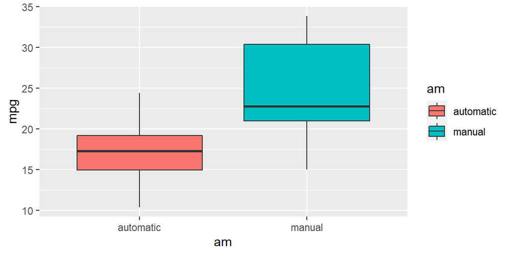

This plot gives a rough estimate that the mpg for manual is better than that of automatic transmission.  
Let’s dig into it and try to fit a linear regression model which may give a better picture of it.  
We also find that:  
- cyl,gear and carb are discrete variables.  
- vs and am are factor variables.  
- mpg,disp,hp,drat,wt and qsec are continuous variables.

## Model Selection

[output not shown]

Let’s fit the model with different parameters depending upon their correlation with the mpg and see which one fits the best.

```
## Analysis of Variance Table
##
## Model 1: mpg ~ disp + am
## Model 2: mpg ~ disp + am + wt
## Model 3: mpg ~ disp + am + wt + hp
## Model 4: mpg ~ disp + am + wt + hp + drat
## Model 5: mpg ~ disp + am + wt + hp + drat + qsec
##   Res.Df    RSS Df Sum of Sq       F   Pr(>F)
## 1     29 300.28
## 2     28 246.56  1    53.725  8.9486 0.006164 **
## 3     27 179.91  1    66.649 11.1012 0.002685 **
## 4     26 175.67  1     4.240  0.7062 0.408668
## 5     25 150.09  1    25.574  4.2598 0.049551 *
## ---
## Signif. codes:  0 '***' 0.001 '**' 0.01 '*' 0.05 '.' 0.1 ' ' 1
```

## Analysing

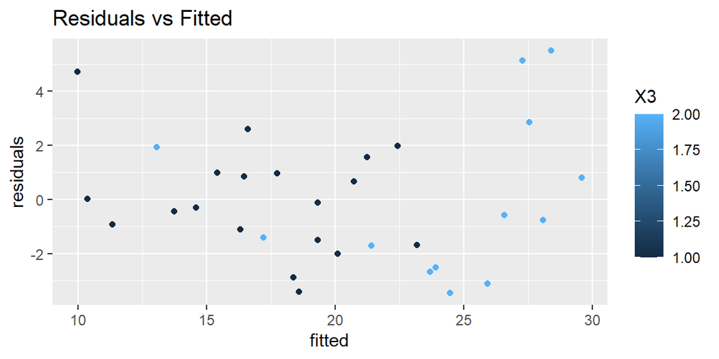

```
##                 Estimate Std. Error    t value     Pr(>|t|)
## (Intercept) 34.209443370 2.82282610 12.1188632 1.979953e-12
## disp         0.002489354 0.01037681  0.2398959 8.122229e-01
## ammanual     2.159270737 1.43517565  1.5045341 1.440531e-01
## wt          -3.046747000 1.15711931 -2.6330448 1.382936e-02
## hp          -0.039323213 0.01243358 -3.1626624 3.842032e-03
```

The coefficient corresponding to “ammanual” suggests that keeping the other covariates constant, the **mean mpg for manual transmission is greater than that of automatc transmission** by 2.1592707 with the p-value of 0.1440531.  
Also the coefficient corresponding to displ suggests that there is a very *minor increase in the mpg with displacement* keeping other covariates constant.  
The coefficient corresponding to weight suggests that *wt has a negative impact on the the mpg* keeping others constant.  
Also, there is a very *minor decrease in the mpg with hp* keeping other covariates constant.

## Appendix Figures

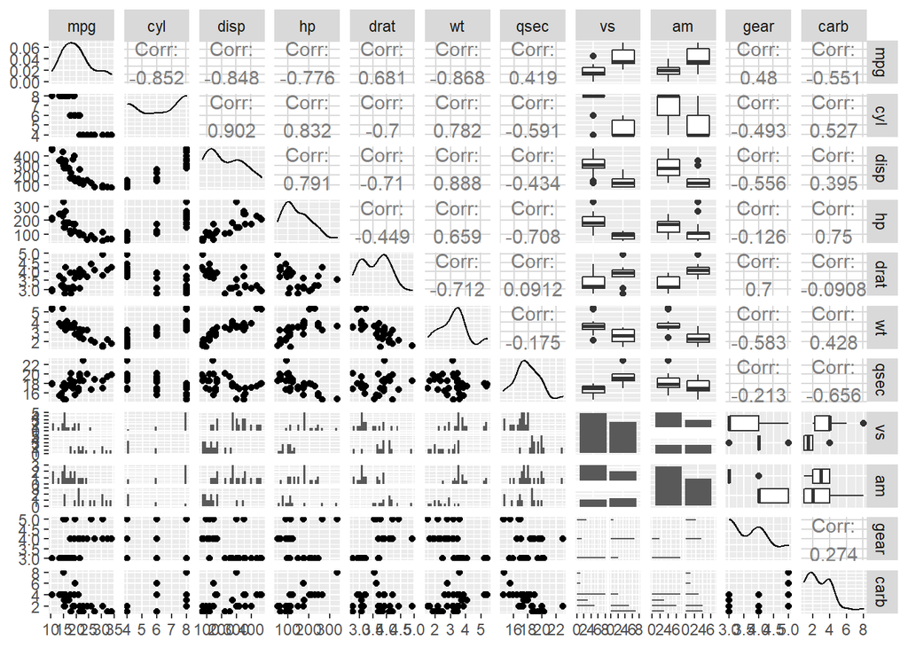

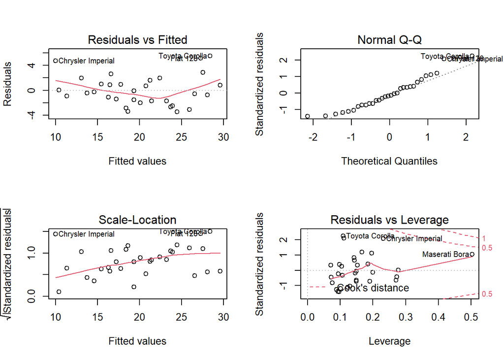